# Work in progess...

```python
import pandas as pd
import pyreadr
import seaborn as sns
import matplotlib.pyplot as plt
import numpy as np
import shap
import statsmodels.formula.api as smf

from darts import TimeSeries
from darts.dataprocessing.transformers import Scaler
from darts.models import LinearRegressionModel

from itertools import product

# from tsfeatures import tsfeatures
from tsfresh import extract_features

from sklearn.cluster import KMeans
from sklearn.metrics import mean_squared_error, r2_score, mean_absolute_error

from scipy import stats
from scipy.stats import f_oneway
from statsmodels.stats.multicomp import pairwise_tukeyhsd
```

## Get era5 data (and keep Fennoscandia?)

```python
# get era5 data

era = pyreadr.read_r('../Data/era5_met.rds')[None]
era['date'] = pd.to_datetime(era['date'])
era['year'] = era['date'].dt.year
era['month'] = era['date'].dt.month
```

```python
era
```

|  | station_id | date | tair | tp | sf | year | month |
| --- | --- | --- | --- | --- | --- | --- | --- |
| 0 | 3_1 | 1960-01-01 | 270.935638 | 1.024788e-02 | 1.024122e-02 | 1960 | 1 |
| 1 | 3_1 | 1960-01-02 | 268.549255 | 8.457695e-03 | 8.453619e-03 | 1960 | 1 |
| 2 | 3_1 | 1960-01-03 | 265.638245 | 1.111615e-06 | 5.234033e-07 | 1960 | 1 |
| 3 | 3_1 | 1960-01-04 | 264.218536 | 1.451688e-05 | 1.340872e-05 | 1960 | 1 |
| 4 | 3_1 | 1960-01-05 | 265.721497 | 9.060125e-04 | 9.025466e-04 | 1960 | 1 |
| ... | ... | ... | ... | ... | ... | ... | ... |
| 28246037 | 1177_1 | 2024-06-26 | 287.689789 | 2.659548e-04 | 0.000000e+00 | 2024 | 6 |
| 28246038 | 1177_1 | 2024-06-27 | 285.414764 | 1.099903e-03 | 0.000000e+00 | 2024 | 6 |
| 28246039 | 1177_1 | 2024-06-28 | 284.358337 | 4.007968e-03 | 1.303852e-08 | 2024 | 6 |
| 28246040 | 1177_1 | 2024-06-29 | 286.996796 | 7.222891e-05 | 0.000000e+00 | 2024 | 6 |
| 28246041 | 1177_1 | 2024-06-30 | 281.944458 | 9.942800e-07 | 0.000000e+00 | 2024 | 6 |

28246042 rows × 7 columns

```python
lakes = pyreadr.read_r('../Data/ltbl_ice.rds')[None]
fs_lakes = set(lakes.loc[lakes['lon_wgs84'] > 0, 'station_id'].unique())
fin_lakes = set(lakes.loc[lakes['country'] == 'FI', 'station_id'].unique())
```

```python
# era = era.loc[era['station_id'].isin(fs_lakes), :]
```

## Trend analysis for ice data only

```python
ice = pyreadr.read_r('../Data/data_ip.rds')[None]

ice['ice_on'] = pd.to_datetime(ice['ice_on'])
ice['ice_off'] = pd.to_datetime(ice['ice_off'])
ice['year'] = ice['year'].astype(int)

# keep fs lakes
# ice = ice.loc[ice['station_id'].isin(fs_lakes), :]

# keep where both not null
ice = ice[ice[['ice_on', 'ice_off']].notnull().all(axis=1)]

# cut to same dates as in era and subset to same stations
ice = ice.loc[ice['ice_on'] >= era['date'].min(), :]
ice = ice.loc[ice['ice_off'] <= era['date'].max(), :]
```

```python
bins = pd.interval_range(start=ice['year'].min(), end=ice['year'].max(),
                        periods=4)
bins
```

```
IntervalIndex([(1960, 1976], (1976, 1992], (1992, 2008], (2008, 2024]], dtype='interval[int64, right]')
```

```python
ice['bin'] = pd.cut(ice['year'], bins)
ice
```

|  | station_id | year | ice_on | ice_off | bin |
| --- | --- | --- | --- | --- | --- |
| 11 | 3_1 | 1961 | 1960-11-01 | 1961-05-30 | (1960, 1976] |
| 12 | 3_1 | 1962 | 1961-11-28 | 1962-05-30 | (1960, 1976] |
| 13 | 3_1 | 1963 | 1962-11-18 | 1963-05-24 | (1960, 1976] |
| 14 | 3_1 | 1964 | 1963-11-12 | 1964-05-30 | (1960, 1976] |
| 15 | 3_1 | 1965 | 1964-11-09 | 1965-06-02 | (1960, 1976] |
| ... | ... | ... | ... | ... | ... |
| 37319 | 1196_1 | 2020 | 2019-11-12 | 2020-03-12 | (2008, 2024] |
| 37320 | 1196_1 | 2021 | 2020-12-06 | 2021-03-20 | (2008, 2024] |
| 37321 | 1196_1 | 2022 | 2021-12-07 | 2022-03-25 | (2008, 2024] |
| 37322 | 1196_1 | 2023 | 2022-11-21 | 2023-03-20 | (2008, 2024] |
| 37323 | 1196_1 | 2024 | 2023-12-13 | 2024-02-28 | (2008, 2024] |

25672 rows × 5 columns

```python
def is_complete(_bin, group):
    # assume right interval

    years_in_group = set(group['year'].unique())
    years_in_bin = set(range(_bin.left+1, _bin.right+1))

    return len(years_in_bin.difference(years_in_group)) == 0
```

```python
gb = ice.groupby([pd.cut(ice['year'], bins), 'station_id'])

n_complete = {}
complete_groups = []

for idx, (group_id, group_df) in enumerate(gb):
    _bin = group_df['bin'].iloc[0]

    if is_complete(_bin, group_df):
        complete_groups.append(group_df)
        try:
            n_complete[_bin] += 1
        except KeyError:
            n_complete[_bin] = 1

print(n_complete)
```

```
{Interval(1960, 1976, closed='right'): 264, Interval(1976, 1992, closed='right'): 236, Interval(1992, 2008, closed='right'): 88, Interval(2008, 2024, closed='right'): 38}
```

```python
ice = pd.concat(complete_groups)
```

```python
ice['ice_on'] = pd.to_datetime(ice['ice_on'], format='%Y')
ice['ice_off'] = pd.to_datetime(ice['ice_off'], format='%Y')
```

#### Plot

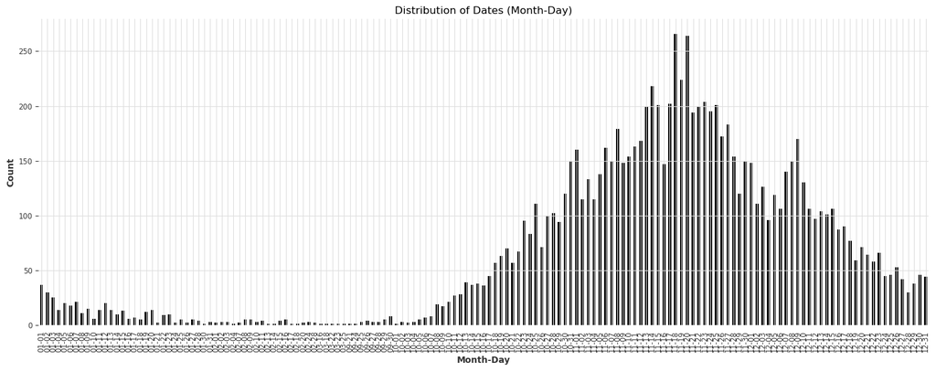

```python
# what's the earliest ice_on?
month_days = ice['ice_on'].dt.strftime('%m-%d').value_counts().sort_index()

plt.figure(figsize=(15, 6))
month_days.plot(kind='bar')
plt.title('Distribution of Dates (Month-Day)')
plt.xlabel('Month-Day')
plt.ylabel('Count')
plt.xticks(rotation=90)
plt.tight_layout()
plt.show()
```

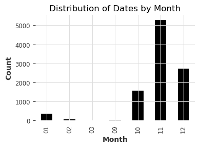

```python
month_counts = ice['ice_on'].dt.strftime('%m').value_counts().sort_index()

plt.figure(figsize=(4, 3))
month_counts.plot(kind='bar')
plt.title('Distribution of Dates by Month')
plt.xlabel('Month')
plt.ylabel('Count')
plt.tight_layout()
plt.show()
```

Data in the Northern hemisphere, calculate distance to 1st of January this year if ice on before April, to 1st Jan next year if after April.

```python
before_april = ice['ice_on'].dt.month < 4

ice['jan_1_current_year'] = pd.to_datetime(ice['ice_on'].dt.year.astype(str) + '-01-01')
ice['jan_1_next_year'] = pd.to_datetime((ice['ice_on'].dt.year + 1).astype(str) + '-01-01')

#ice['distance_to_jan_1'] = np.where(
#    before_april,
#    (ice['ice_on'] - ice['jan_1_current_year']).dt.days,
#    (ice['jan_1_next_year'] - ice['ice_on']).dt.days
#)

ice['distance_to_jan_1'] = np.where(
    before_april,
    (ice['jan_1_current_year'] - ice['ice_on']).dt.days,
    (ice['jan_1_next_year'] - ice['ice_on']).dt.days
)


# Drop intermediate columns if not needed
ice.drop(columns=['jan_1_current_year', 'jan_1_next_year'], inplace=True)

# ice['year_on_diff'] = (pd.to_datetime(ice['ice_on'], format='%Y') - pd.to_datetime(ice['ice_on'])).dt.days
# ice
```

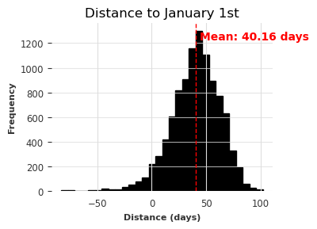

```python
plt.figure(figsize=(4, 3))
plt.hist(ice['distance_to_jan_1'], bins=30, edgecolor='black')

# Customize the plot
plt.title('Distance to January 1st', fontsize=12)
plt.xlabel('Distance (days)', fontsize=8)
plt.ylabel('Frequency', fontsize=8)
plt.grid(axis='y', alpha=0.75)

# Add mean line
mean_distance = ice['distance_to_jan_1'].mean()
plt.axvline(mean_distance, color='red', linestyle='dashed', linewidth=1)
plt.text(mean_distance*1.1, plt.ylim()[1]*0.9, f'Mean: {mean_distance:.2f} days',
         color='red', fontweight='bold')

# Show the plot
plt.tight_layout()
plt.show()
```

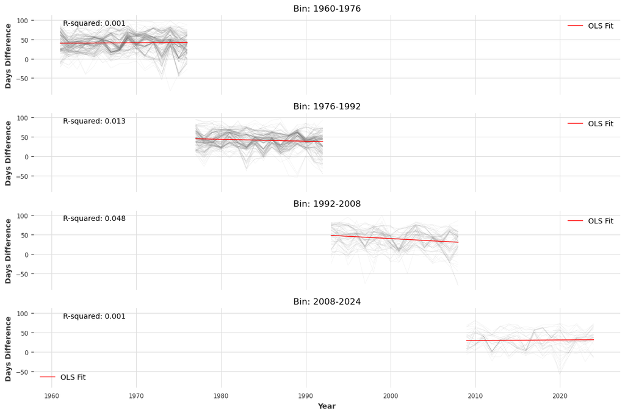

```python
import statsmodels.api as sm

fig, axes = plt.subplots(len(bins), 1, figsize=(12, 8), sharex=True, sharey=True)

for i, bin_interval in enumerate(bins):
    ax = axes[i]
    bin_df = ice[ice['bin'] == bin_interval]

    for station_id in bin_df['station_id'].unique():
        station_df = bin_df[bin_df['station_id'] == station_id]

        # plot data
        ax.plot(station_df['year'], station_df['distance_to_jan_1'],
                label='', color='gray', alpha=0.5, linewidth=0.1)

    # Make and plot OLS model

    # Prepare data for regression
    X = bin_df['year'].values
    y = bin_df['distance_to_jan_1'].values

    # Add constant and squared term for polynomial regression
    # X = sm.add_constant(np.column_stack((X, X**2)))
    X = sm.add_constant(X)

    # Fit the model
    model = sm.OLS(y, X).fit()

    # Generate predictions
    x_smooth = np.linspace(X[:, 1].min(), X[:, 1].max(), 100)
    # X_pred = sm.add_constant(np.column_stack((x_smooth, x_smooth**2)))
    X_pred = sm.add_constant(x_smooth)
    y_pred = model.predict(X_pred)

    ax.plot(x_smooth, y_pred, color='red', linewidth=1,
            label='OLS Fit')

    # Add R-squared value to the plot
    ax.text(0.05, 0.95, f'R-squared: {model.rsquared:.3f}',
            transform=ax.transAxes,
            verticalalignment='top')


    ax.set_title(f'Bin: {bin_interval.left}-{bin_interval.right}')
    ax.set_ylabel('Days Difference')
    ax.legend()

plt.xlabel('Year')
plt.tight_layout()
```

### Box-plots

```python
# Group data by bins
box_data = [ice[ice['bin'] == bin_interval]['distance_to_jan_1'] for bin_interval in bins]

# Perform one-way ANOVA
f_stat, p_value = f_oneway(*box_data)
print(f"ANOVA F-statistic: {f_stat:.2f}, p-value: {p_value:.4f}")

# Perform Tukey's HSD post-hoc test if ANOVA is significant
if p_value < 0.05:
    # Create a DataFrame for Tukey's HSD
    tukey_data = pd.DataFrame({
        'distance_to_jan_1': ice['distance_to_jan_1'],
        'bin': ice['bin'].apply(lambda x: f'{x.left}-{x.right}')
    })

    tukey_result = pairwise_tukeyhsd(tukey_data['distance_to_jan_1'], tukey_data['bin'])
    print(tukey_result)

    # Extract group labels from Tukey's HSD results
    group_labels = {group: label for group, label in zip(tukey_result.groupsunique, tukey_result._results_table.data[1:])}
else:
    print("No significant differences found between groups.")
    group_labels = {f'{bin_interval.left}-{bin_interval.right}': 'a' for bin_interval in bins}
```

```
ANOVA F-statistic: 55.99, p-value: 0.0000
    Multiple Comparison of Means - Tukey HSD, FWER=0.05
===========================================================
  group1    group2  meandiff p-adj   lower    upper  reject
-----------------------------------------------------------
1960-1976 1976-1992   0.7638 0.3898  -0.4779  2.0055  False
1960-1976 1992-2008  -1.6982 0.0516  -3.4043   0.008  False
1960-1976 2008-2024 -11.1742    0.0 -13.5792 -8.7692   True
1976-1992 1992-2008  -2.4619 0.0015  -4.1933 -0.7306   True
1976-1992 2008-2024  -11.938    0.0 -14.3608 -9.5151   True
1992-2008 2008-2024   -9.476    0.0 -12.1667 -6.7854   True
-----------------------------------------------------------
```

```python
# https://github.com/timyerg/cld4py/blob/main/cld4py/cld4py.py
import string

def assign_letters(df, G1, G2, P, alpha=.05,
           order=None, data=None, vals=None, group=None, param=True):
    """
    Function to apply compact letter display for pairwise contrasts.
    Groups with no significant differences share a letter.

    Parameters:

      Required:
        df    - dataframe with contrasts (pairwise comparisons).
        G1, G2 - columns in contrasts df with compared groups.
        P      - column in contrasts df with p-value (adjusted, right?).

      Optional:
        alpha  - sigificance level (default 0.05).
        order  - None (default), list or ['ascending', 'descending'].
                 This parameter will define the order of assigned letters.
                 None - alphabetical order will be applied.
                 List - order of groups will be defined by that list.
                 String 'ascending' or 'descending' requires parameters
                 'data', 'values' and 'group' to order groups by the mean.
        data   - dataframe with values that were compared to get contrasts.
        vals   - column in data with compared values.
        group  - column in data with group information.
        param  - wether sort by mean (True; default) or median (False).
    """

    #helper function to check p
    def is_sign(lv1, lv2, df=df, alpha=alpha):
        return df.loc[(df[G1]==lv1)&(df[G2]==lv2)|(df[G1]==lv2)&(df[G2]==lv1),P].iloc[0] < alpha

    letters = string.ascii_lowercase
    df[P] = df[P].apply(pd.to_numeric)

    #define order
    if order == None:
        order = sorted(set(df[G1].tolist() + df[G2].tolist()))
    if order in ['ascending', 'descending']:
        asc = order=='ascending'
        data[vals] = data[vals].apply(pd.to_numeric)
        if param:
            order = pd.DataFrame(data.groupby(group)[vals].mean()).sort_values(vals, ascending=asc).index.tolist()
        else:
            order = pd.DataFrame(data.groupby(group)[vals].median()).sort_values(vals, ascending=asc).index.tolist()
    #assign letters
    draft, sets = {}, []
    for i, l1 in enumerate(order):
        draft.update({i: {l1}})
        for l2 in order:
            if l1 != l2 and not any([is_sign(l1,l2)]+[is_sign(l,l2) for l in draft[i]]):
                    draft[i].add(l2)
    [sets.append(v) for v in draft.values() if v not in sets]
    cld = pd.DataFrame(columns=['Group', 'Letters'])
    for i,l in enumerate(order):
        cld.loc[i, ['Group', 'Letters']] = l, ''.join([letters[j] for j,s in enumerate(sets) if l in s])
    return cld.set_index('Group')
```

```python
df = pd.DataFrame(tukey_result._results_table.data)
df.columns = df.iloc[0]
df = df.drop(df.index[0])

group_labels = assign_letters(df, 'group1', 'group2', 'p-adj').to_dict()['Letters']
```

```python
def validate_labels(group_labels, tukey_results):
    df = pd.DataFrame(tukey_result._results_table.data)
    df.columns = df.iloc[0]
    df = df.drop(df.index[0])
    # print(df)

    groups = list(group_labels.keys())

    for g1, g2 in zip(groups[:-1], groups[1:]):
        rej = df.loc[(df['group1'] == g1) & (df['group2'] == g2), 'reject'].values[0]
        # print(f'{g1} {g2} {rej}')

        if rej == True:
            #print(set(group_labels[g1]))
            #print(set(group_labels[g2]))
            #print(set(group_labels[g1]).intersection(set(group_labels[g1])))
            assert len(set(group_labels[g1]).intersection(set(group_labels[g2]))) == 0

validate_labels(group_labels, tukey_result)
```

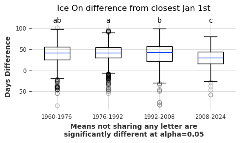

```python
# Plot box plots with significance labels https://github.com/timyerg/cld4py/blob/main/cld4py/cld4py.py

fig, ax = plt.subplots(figsize=(5, 3))

positions = range(1, len(bins) + 1)

box_plot = ax.boxplot(box_data, positions=positions, widths=0.5)

for flier in box_plot['fliers']:
    flier.set(marker='o',
              markerfacecolor='none',
              markeredgecolor='black',
              alpha=0.25,
              markersize=6)

# Set x-tick labels to bin ranges
ax.set_xticks(positions)
ax.set_xticklabels([f'{bin_interval.left}-{bin_interval.right}' for bin_interval in bins])

# Add significance labels above each box plot
for i, bin_interval in enumerate(bins):
    label = group_labels.get(f'{bin_interval.left}-{bin_interval.right}', 'NA')
    ax.text(positions[i], 110, # max(box_data) + 0.5
            label,
            horizontalalignment='center', verticalalignment='bottom')

ax.set_xlabel('Means not sharing any letter are\nsignificantly different at alpha=0.05')
ax.set_ylabel('Days Difference')
ax.set_title('Ice On difference from closest Jan 1st\n')

plt.tight_layout()
plt.show()
```

### Ice on trends with Darts and univariate clustering

```python
ice.dtypes
```

```
station_id                   object
year                          int64
ice_on               datetime64[ns]
ice_off              datetime64[ns]
bin                        category
distance_to_jan_1             int64
dtype: object
```

#### Group by station and year bin

```python
grouped = ice.groupby(['station_id', 'bin'])

time_series_dict = {}
for (station_id, bin_label), group in grouped:
    ts = TimeSeries.from_dataframe(
        group,
        time_col='year',
        value_cols='distance_to_jan_1',
    )
    time_series_dict[(station_id, bin_label)] = ts
```

# Normalize the time series scaler = Scaler() scaled_time_series_dict = { key: scaler.fit_transform(ts) for key, ts in time_series_dict.items() } # Fit a linear regression model to detect trends for each time series trend_dict = {} for key, ts in scaled_time_series_dict.items(): model = LinearRegressionModel(lags=12) model.fit(ts) prediction = model.predict(len(ts)) trend_dict[key] = prediction # Print trends for station and bin # for key, trend in trend_dict.items(): # print(f"Trend for {key}: {trend}")

#### Second order OLS

```python
lin_terms = []
quad_terms = []
keys = []

for key, ts in time_series_dict.items():
    keys.append(key)

    x = ts.time_index.values
    y = ts.values().flatten()

    data = pd.DataFrame({'x': x, 'y': y})
    model = smf.ols(formula='y ~ x + I(x**2)', data=data).fit()
    linear_term = model.params['x']
    quadratic_term = model.params['I(x ** 2)']

    lin_terms.append(linear_term)
    quad_terms.append(quadratic_term)
```

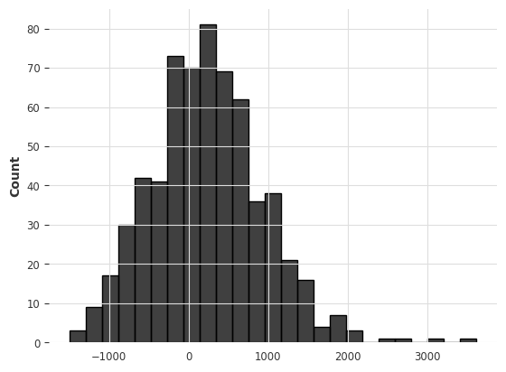

```python
sns.histplot(lin_terms);
```

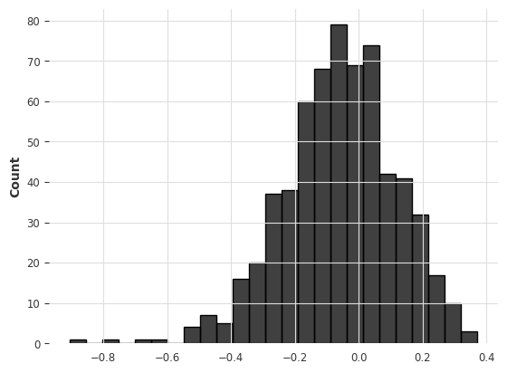

```python
sns.histplot(quad_terms);
```

```python
print(model.summary())
```

```
                            OLS Regression Results
==============================================================================
Dep. Variable:                      y   R-squared:                       0.137
Model:                            OLS   Adj. R-squared:                  0.004
Method:                 Least Squares   F-statistic:                     1.031
Date:                Thu, 03 Apr 2025   Prob (F-statistic):              0.384
Time:                        16:04:53   Log-Likelihood:                -54.781
No. Observations:                  16   AIC:                             115.6
Df Residuals:                      13   BIC:                             117.9
Df Model:                           2
Covariance Type:            nonrobust
==============================================================================
                 coef    std err          t      P>|t|      [0.025      0.975]
------------------------------------------------------------------------------
Intercept   5.968e+05   4.29e+05      1.390      0.188   -3.31e+05    1.52e+06
x           -601.5838    432.595     -1.391      0.188   -1536.149     332.981
I(x ** 2)      0.1516      0.109      1.391      0.188      -0.084       0.387
==============================================================================
Omnibus:                        0.283   Durbin-Watson:                   2.210
Prob(Omnibus):                  0.868   Jarque-Bera (JB):                0.262
Skew:                          -0.244   Prob(JB):                        0.877
Kurtosis:                       2.605   Cond. No.                     8.21e+11
==============================================================================

Notes:
[1] Standard Errors assume that the covariance matrix of the errors is correctly specified.
[2] The condition number is large, 8.21e+11. This might indicate that there are
strong multicollinearity or other numerical problems.
```

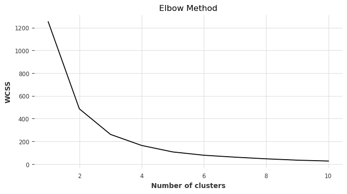

```python
X = np.array([lin_terms, quad_terms]).T

# Normalize by column, unit variance, zero mean
X = (X - X.mean(axis=0)) / X.std(axis=0)

# Perform elbow method to find optimal number of clusters
# wcss == within cluster sum of squares
wcss = []
max_clusters = 10
for i in range(1, max_clusters + 1):
    kmeans = KMeans(n_clusters=i, init='k-means++', max_iter=300, n_init=10, random_state=0)
    kmeans.fit(X)
    wcss.append(kmeans.inertia_)

# Plot the elbow curve
plt.figure(figsize=(8, 4))
plt.plot(range(1, max_clusters + 1), wcss)
plt.title('Elbow Method')
plt.xlabel('Number of clusters')
plt.ylabel('WCSS')
plt.show()
```

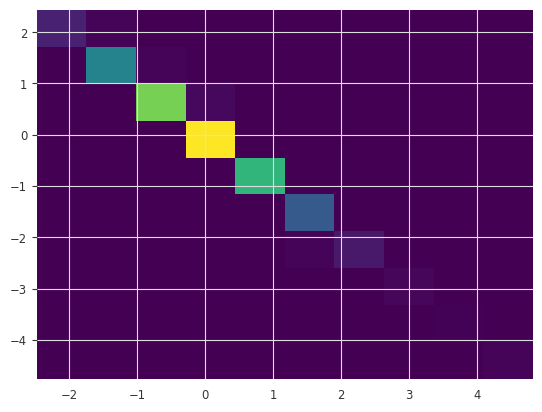

```python
plt.hist2d(X[:,0], X[:,1], cmap='viridis');
```

```
                            OLS Regression Results
==============================================================================
Dep. Variable:                      y   R-squared:                       0.137
Model:                            OLS   Adj. R-squared:                  0.004
Method:                 Least Squares   F-statistic:                     1.031
Date:                Thu, 03 Apr 2025   Prob (F-statistic):              0.384
Time:                        16:04:53   Log-Likelihood:                -54.781
No. Observations:                  16   AIC:                             115.6
Df Residuals:                      13   BIC:                             117.9
Df Model:                           2
Covariance Type:            nonrobust
==============================================================================
                 coef    std err          t      P>|t|      [0.025      0.975]
------------------------------------------------------------------------------
Intercept   5.968e+05   4.29e+05      1.390      0.188   -3.31e+05    1.52e+06
x           -601.5838    432.595     -1.391      0.188   -1536.149     332.981
I(x ** 2)      0.1516      0.109      1.391      0.188      -0.084       0.387
==============================================================================
Omnibus:                        0.283   Durbin-Watson:                   2.210
Prob(Omnibus):                  0.868   Jarque-Bera (JB):                0.262
Skew:                          -0.244   Prob(JB):                        0.877
Kurtosis:                       2.605   Cond. No.                     8.21e+11
==============================================================================

Notes:
[1] Standard Errors assume that the covariance matrix of the errors is correctly specified.
[2] The condition number is large, 8.21e+11. This might indicate that there are
strong multicollinearity or other numerical problems.
```

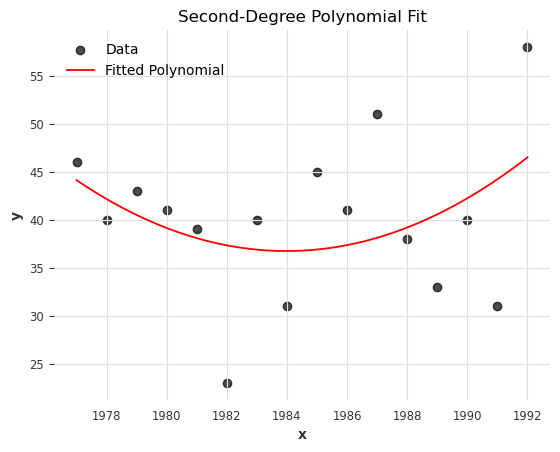

```python
data = pd.DataFrame({'x': x, 'y': y})

model = smf.ols(formula='y ~ x + I(x**2)', data=data).fit()
print(model.summary())


# Generate predictions for plotting
x_pred = np.linspace(data['x'].min(), data['x'].max(), 200)  # Generate smooth x values for the curve
data_pred = pd.DataFrame({'x': x_pred})
data_pred['y_pred'] = model.predict(data_pred)

# Plot the original data and the fitted curve
plt.scatter(data['x'], data['y'], label='Data', alpha=0.7)
plt.plot(data_pred['x'], data_pred['y_pred'], color='red', label='Fitted Polynomial')
plt.xlabel('x')
plt.ylabel('y')
plt.title('Second-Degree Polynomial Fit')
plt.legend()
plt.show()
```

```python
kmeans = KMeans(n_clusters=3, random_state=42)
clusters = kmeans.fit_predict(X)

# Map clusters back to keys (station_id, bin)
cluster_results = pd.DataFrame({'key': keys, 'cluster': clusters})

print(cluster_results)
```

```
                        key  cluster
0    (1015_1, (1976, 1992])        0
1    (1034_1, (1960, 1976])        2
2    (1035_1, (1960, 1976])        2
3    (1039_1, (1976, 1992])        2
4    (1040_1, (1976, 1992])        0
..                      ...      ...
621   (983_1, (1960, 1976])        1
622   (992_1, (1960, 1976])        1
623   (992_1, (1976, 1992])        0
624   (993_1, (1976, 1992])        0
625   (998_1, (1976, 1992])        2

[626 rows x 2 columns]
```

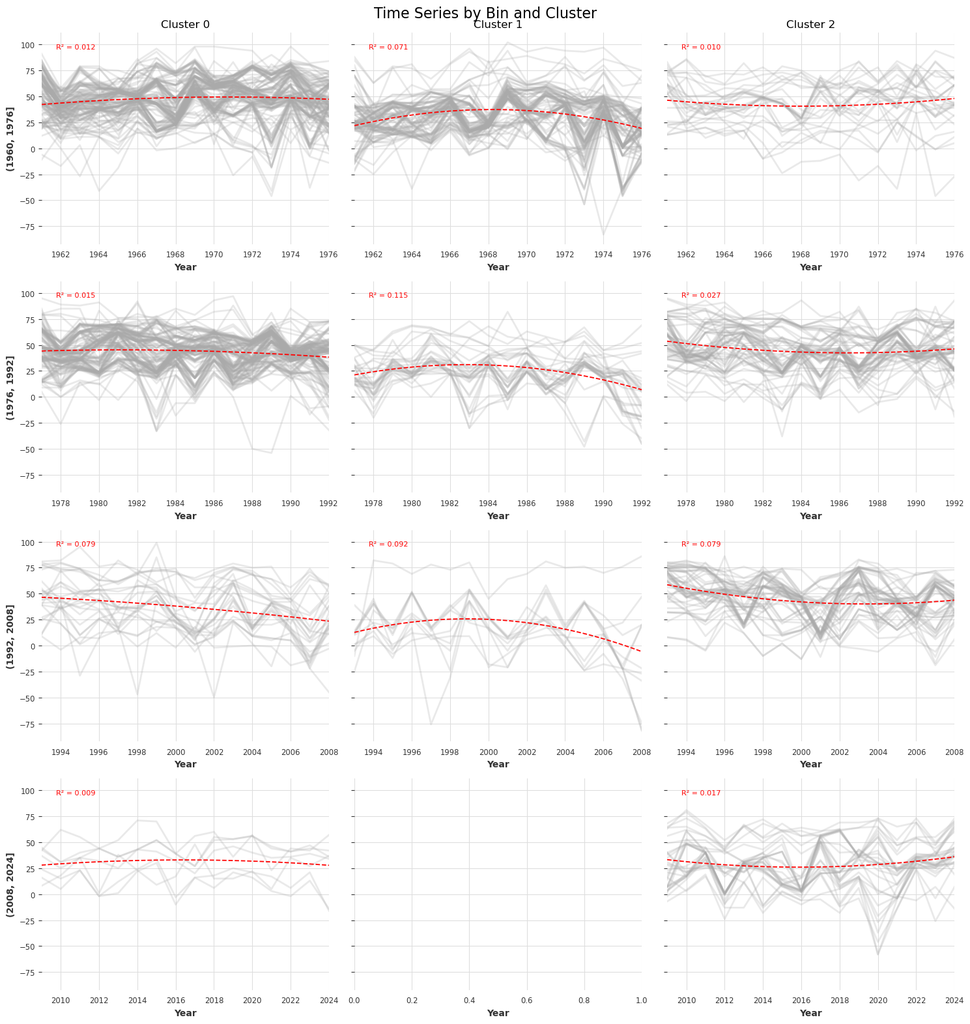

```python
import warnings
warnings.filterwarnings('ignore')

# Get unique bins and clusters
unique_bins = sorted(set(key[1] for key in time_series_dict.keys()))
unique_clusters = sorted(cluster_results['cluster'].unique())

# Set up the plot grid
n_rows = len(unique_bins)
n_cols = len(unique_clusters)
fig, axes = plt.subplots(n_rows, n_cols, figsize=(5*n_cols, 4*n_rows), sharex=False, sharey=True)
fig.suptitle("Time Series by Bin and Cluster", fontsize=16)

# Plot time series for each bin and cluster
for (row, bin_label), (col, cluster) in product(enumerate(unique_bins), enumerate(unique_clusters)):
    ax = axes[row, col]

    # Filter time series for this bin and cluster
    cluster_keys = cluster_results[(cluster_results['cluster'] == cluster) &
                                   (cluster_results['key'].apply(lambda x: x[1] == bin_label))]['key']

    all_x = []
    all_y = []

    for i, key in enumerate(cluster_keys):
        ts = time_series_dict[key]
        ts.plot(ax=ax, label=None, color="#aaaaaa", alpha=0.25)

        # Collect all x and y values for linear regression
        all_x.extend(ts.time_index.values)
        all_y.extend(ts.values().flatten())

    # Perform linear regression if we have data
    if all_x and all_y:

        data = pd.DataFrame({'x': all_x, 'y': all_y})
        model = smf.ols(formula='y ~ x + I(x**2)', data=data).fit()

        # Generate predictions for plotting
        x_pred = np.linspace(data['x'].min(), data['x'].max(), 100)
        data_pred = pd.DataFrame({'x': x_pred})
        data_pred['y_pred'] = model.predict(data_pred)

        r_squared = model.rsquared

        # Plot the OLS fit
        ax.plot(np.linspace(min(all_x), max(all_x), 100),
                data_pred['y_pred'], color='red', linestyle='--')

        # x_range = np.array([min(all_x), max(all_x)])
        # ax.plot(x_range, slope * x_range + intercept, color='red', linestyle='--')

        # Add R-squared value to the plot
        # ax.text(0.05, 0.95, f'R² = {r_squared:.3f}', transform=ax.transAxes,
        #         verticalalignment='top', fontsize=10, color='red')
        ax.text(0.05, 0.95, f'R² = {r_squared:.3f}',
                transform=ax.transAxes,
                verticalalignment='top', fontsize=8, color='red')

    # Set titles and labels
    if row == 0:
        ax.set_title(f"Cluster {cluster}")
    if col == 0:
        ax.set_ylabel(bin_label)

    ax.set_xlabel("Year")

    # Adjust x-axis to fill the panel
    if all_x:
        ax.set_xlim(min(all_x), max(all_x))

    # Remove legend
    ax.legend().remove()

# Adjust layout and display
plt.tight_layout()
plt.show()
```

```python
slopes = []
keys = []

for key, ts in time_series_dict.items():
    keys.append(key)

    x = ts.time_index.values
    y = ts.values().flatten()

    data = pd.DataFrame({'x': x, 'y': y})
    model = smf.ols(formula='y ~ x', data=data).fit()
    linear_term = model.params['x']
    # quadratic_term = model.params['I(x ** 2)']

    slopes.append(linear_term)
```

```python
X = np.array(slopes).reshape(-1, 1)
```

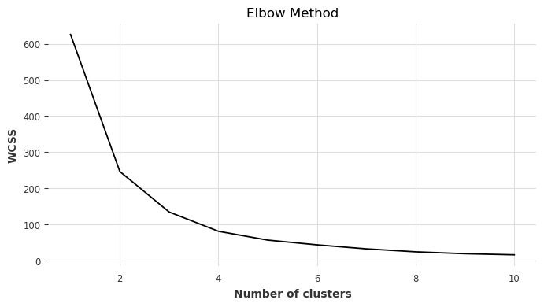

```python
# Normalize by column, unit variance, zero mean
X = (X - X.mean(axis=0)) / X.std(axis=0)

# Perform elbow method to find optimal number of clusters
# wcss == within cluster sum of squares
wcss = []
max_clusters = 10
for i in range(1, max_clusters + 1):
    kmeans = KMeans(n_clusters=i, init='k-means++', max_iter=300, n_init=10, random_state=0)
    kmeans.fit(X)
    wcss.append(kmeans.inertia_)

# Plot the elbow curve
plt.figure(figsize=(8, 4))
plt.plot(range(1, max_clusters + 1), wcss)
plt.title('Elbow Method')
plt.xlabel('Number of clusters')
plt.ylabel('WCSS')
plt.show()
```

```python
kmeans = KMeans(n_clusters=2, random_state=42)
clusters = kmeans.fit_predict(X)

# Map clusters back to keys (station_id, bin)
cluster_results = pd.DataFrame({'key': keys, 'cluster': clusters})

print(cluster_results)
```

```
                        key  cluster
0    (1015_1, (1976, 1992])        0
1    (1034_1, (1960, 1976])        0
2    (1035_1, (1960, 1976])        0
3    (1039_1, (1976, 1992])        0
4    (1040_1, (1976, 1992])        0
..                      ...      ...
621   (983_1, (1960, 1976])        0
622   (992_1, (1960, 1976])        0
623   (992_1, (1976, 1992])        0
624   (993_1, (1976, 1992])        0
625   (998_1, (1976, 1992])        0

[626 rows x 2 columns]
```

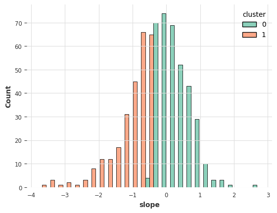

```python
_df = pd.DataFrame({'slope': slopes, 'cluster': cluster_results['cluster']})

sns.histplot(data=_df, x='slope', hue='cluster', multiple='dodge', palette='Set2')
```

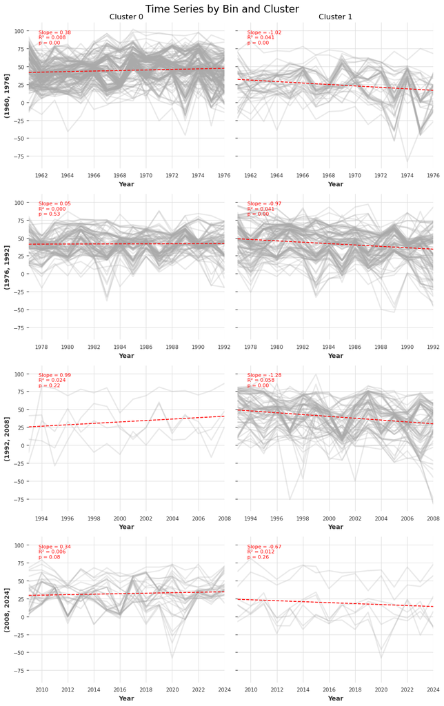

```python
import warnings
warnings.filterwarnings('ignore')

# Get unique bins and clusters
unique_bins = sorted(set(key[1] for key in time_series_dict.keys()))
unique_clusters = sorted(cluster_results['cluster'].unique())

# Set up the plot grid
n_rows = len(unique_bins)
n_cols = len(unique_clusters)
fig, axes = plt.subplots(n_rows, n_cols, figsize=(5*n_cols, 4*n_rows), sharex=False, sharey=True)
fig.suptitle("Time Series by Bin and Cluster", fontsize=16)

# Plot time series for each bin and cluster
for (row, bin_label), (col, cluster) in product(enumerate(unique_bins), enumerate(unique_clusters)):
    ax = axes[row, col]

    # Filter time series for this bin and cluster
    cluster_keys = cluster_results[(cluster_results['cluster'] == cluster) &
                                   (cluster_results['key'].apply(lambda x: x[1] == bin_label))]['key']

    all_x = []
    all_y = []

    for i, key in enumerate(cluster_keys):
        ts = time_series_dict[key]
        ts.plot(ax=ax, label=None, color="#aaaaaa", alpha=0.25)

        # Collect all x and y values for linear regression
        all_x.extend(ts.time_index.values)
        all_y.extend(ts.values().flatten())

    # Perform linear regression if we have data
    if all_x and all_y:
        slope, intercept, r_value, p_value, _ = stats.linregress(all_x, all_y)
        r_squared = r_value**2

        # Plot the linear fit
        x_range = np.array([min(all_x), max(all_x)])
        ax.plot(x_range, slope * x_range + intercept, color='red', linestyle='--')

        # Add R-squared value to the plot
        # ax.text(0.05, 0.95, f'R² = {r_squared:.3f}', transform=ax.transAxes,
        #         verticalalignment='top', fontsize=10, color='red')
        ax.text(0.05, 0.95, f'Slope = {slope:.2f}\nR² = {r_squared:.3f}\np = {p_value:.2f}',
                transform=ax.transAxes,
                verticalalignment='top', fontsize=8, color='red')

    # Set titles and labels
    if row == 0:
        ax.set_title(f"Cluster {cluster}")
    if col == 0:
        ax.set_ylabel(bin_label)

    ax.set_xlabel("Year")

    # Adjust x-axis to fill the panel
    if all_x:
        ax.set_xlim(min(all_x), max(all_x))

    # Remove legend
    ax.legend().remove()

# Adjust layout and display
plt.tight_layout()
plt.show()
```

```python
# Make a df with with cluster id
dfs = []

for bin_label, cluster in product(unique_bins, unique_clusters):
    cluster_keys = cluster_results[(cluster_results['cluster'] == cluster) &
                                   (cluster_results['key'].apply(lambda x: x[1] == bin_label))]['key']

    for key in cluster_keys:
        ts = time_series_dict[key]
        _df = ts.pd_dataframe().reset_index()[['year', 'distance_to_jan_1']]
        _df['cluster'] = cluster
        _df['station_id'] = key[0]
        dfs.append(_df)

df_clustered = pd.concat(dfs)
df_clustered
```

| component | year | distance_to_jan_1 | cluster | station_id |
| --- | --- | --- | --- | --- |
| 0 | 1961 | 39.0 | 0 | 1034_1 |
| 1 | 1962 | 39.0 | 0 | 1034_1 |
| 2 | 1963 | 38.0 | 0 | 1034_1 |
| 3 | 1964 | 35.0 | 0 | 1034_1 |
| 4 | 1965 | 37.0 | 0 | 1034_1 |
| ... | ... | ... | ... | ... |
| 11 | 2020 | 57.0 | 1 | 704_1 |
| 12 | 2021 | 23.0 | 1 | 704_1 |
| 13 | 2022 | 44.0 | 1 | 704_1 |
| 14 | 2023 | 42.0 | 1 | 704_1 |
| 15 | 2024 | 57.0 | 1 | 704_1 |

10016 rows × 4 columns

## Combine with ERA5 and lake data and fit a model to explain cluster id

Start with yearly aggregates.

# Group by station, year, and month, then calculate the mean for temperature and wind aggregated_era = era.groupby(['station_id', 'year']).agg({ 'tair': 'mean', 'tp': 'mean', 'sf': 'mean' }).reset_index() # Drop the separate year and month columns aggregated_era = aggregated_era.sort_values(['station_id', 'year']) aggregated_era

```python
# ice_era = ice.merge(aggregated_era, on=['station_id', 'year'], how='left')
ice_era = ice.merge(era, on=['station_id', 'year'], how='left')
ice_era_stats = ice_era.merge(lakes, on=['station_id'])

del ice_era
```

ice_era_stats['_key'] = ice_era_stats[['station_id', 'bin']].apply(lambda x: (x[0], str(x[1])), axis=1) ice_era_stats = ice_era_stats.merge(cluster_results, on=['_key']) ice_era_stats.drop(columns=['_key', 'key'], inplace=True) ice_era_stats

```python
ice_era_stats = ice_era_stats.merge(df_clustered, on=['year', 'station_id', 'distance_to_jan_1'])


ice_era_stats['cluster'].unique()
```

```
array([0, 1], dtype=int32)
```

```python
# log transform
ice_era_stats['area_ha'] = np.log(ice_era_stats['area_ha'])
```

```python
ice_era_stats.columns
```

```
Index(['station_id', 'year', 'ice_on', 'ice_off', 'bin', 'distance_to_jan_1',
       'date', 'tair', 'tp', 'sf', 'month', 'lake_id', 'country', 'subset',
       'lake_name', 'lat_wgs84', 'lon_wgs84', 'altitude_m', 'area_ha',
       'depth_mean_m', 'depth_max_m', 'cent_lat_wgs84', 'cent_lon_wgs84',
       'cluster'],
      dtype='object')
```

```python
ice_era_stats = ice_era_stats[[
    'station_id', # 'year',
    'distance_to_jan_1', 'date',
    'tair', 'tp', 'sf', # dynamic
    'bin',
    'lat_wgs84', 'altitude_m', 'area_ha', 'depth_mean_m', 'depth_max_m', # statics
    'cluster']]
```

```python
ice_era_stats_long = pd.melt(ice_era_stats,
        # id_vars=['station_id', 'year'],
        id_vars=['station_id', 'date'],
        value_vars=[#'distance_to_jan_1',
                    'tair', 'tp', 'sf',
                    # 'lat_wgs84', 'altitude_m', 'area_ha', 'cluster'
        ],
        var_name='kind',
        value_name='value')
```

```python
ice_era_stats_long
```

|  | station_id | date | kind | value |
| --- | --- | --- | --- | --- |
| 0 | 1034_1 | 1961-01-01 | tair | 240.000687 |
| 1 | 1034_1 | 1961-01-02 | tair | 241.599808 |
| 2 | 1034_1 | 1961-01-03 | tair | 249.894897 |
| 3 | 1034_1 | 1961-01-04 | tair | 251.922150 |
| 4 | 1034_1 | 1961-01-05 | tair | 255.453842 |
| ... | ... | ... | ... | ... |
| 10954051 | 726_1 | 2024-06-26 | sf | 0.000000 |
| 10954052 | 726_1 | 2024-06-27 | sf | 0.000000 |
| 10954053 | 726_1 | 2024-06-28 | sf | 0.000000 |
| 10954054 | 726_1 | 2024-06-29 | sf | 0.000000 |
| 10954055 | 726_1 | 2024-06-30 | sf | 0.000000 |

10954056 rows × 4 columns

```python
len(ice_era_stats_long['station_id'].unique())
```

```
403
```

```python
# ice_era_stats_long['yq'] = ice_era_stats_long.date.dt.quarter.map(str) + "-" + ice_era_stats_long.date.dt.year.map(str)
# ice_era_stats_long
```

```python
# Group by station, year, and month, then calculate the mean for temperature and wind
#ice_era_stats_long = ice_era_stats_long.groupby(['station_id', 'yq', 'kind']).agg({
#    'value': 'mean'
#}).reset_index()

# # Drop the separate year and month columns
# aggregated_era = aggregated_era.sort_values(['station_id', 'year'])
#ice_era_stats_long
```

import random _grouped = ice_era_stats_long.groupby('station_id') random_groups = list(_grouped.groups.keys()) random_groups = random.sample(random_groups, k=min(50, len(random_groups))) ice_era_stats_long = pd.concat([_grouped.get_group(group) for group in random_groups]) ice_era_stats_long

#### Optional: group by year/month/quarter/...

```python
ice_era_stats_long['id'] = (ice_era_stats_long['station_id'] + '__' +
                            ice_era_stats_long['date'].dt.year.map(lambda x: str(x)))
#ice_era_stats_long['id'] = (ice_era_stats_long['station_id'] + '__' +
#                            ice_era_stats_long['yq'].str.split('-').map(lambda x: x[-1]))
ice_era_stats_long
```

|  | station_id | date | kind | value | id |
| --- | --- | --- | --- | --- | --- |
| 0 | 1034_1 | 1961-01-01 | tair | 240.000687 | 1034_1__1961 |
| 1 | 1034_1 | 1961-01-02 | tair | 241.599808 | 1034_1__1961 |
| 2 | 1034_1 | 1961-01-03 | tair | 249.894897 | 1034_1__1961 |
| 3 | 1034_1 | 1961-01-04 | tair | 251.922150 | 1034_1__1961 |
| 4 | 1034_1 | 1961-01-05 | tair | 255.453842 | 1034_1__1961 |
| ... | ... | ... | ... | ... | ... |
| 10954051 | 726_1 | 2024-06-26 | sf | 0.000000 | 726_1__2024 |
| 10954052 | 726_1 | 2024-06-27 | sf | 0.000000 | 726_1__2024 |
| 10954053 | 726_1 | 2024-06-28 | sf | 0.000000 | 726_1__2024 |
| 10954054 | 726_1 | 2024-06-29 | sf | 0.000000 | 726_1__2024 |
| 10954055 | 726_1 | 2024-06-30 | sf | 0.000000 | 726_1__2024 |

10954056 rows × 5 columns

```python
# Define custom feature extraction parameters
custom_fc_parameters = {
    "mean": None,
    "minimum": None,
    "maximum": None,
    "variance": None,
    "standard_deviation": None,
    # "linear_trend": [{"attr": "slope"}],  # positive control
    "number_peaks": [{"n": 7}],             # peak with support of 7 (days)
    # "autocorrelation": [{"lag": 1}],      # kind of like lag
    "skewness": None,
    "kurtosis": None,
    "longest_strike_above_mean": None,
    "longest_strike_below_mean": None,
    "time_reversal_asymmetry_statistic": [{"lag": 7}]
}

## IF RUNNING WITH YEAR

def features_by_group(group):
    print(f'{ group["station_id"].iloc[0] }')
    features = extract_features(group,
                                column_id="station_id",
                                column_sort="yq",
                                column_kind="kind",
                                column_value="value",
                                default_fc_parameters=custom_fc_parameters,
                                disable_progressbar=True)
    return features

#ice_era_feats = ice_era_stats_long.groupby(['id']).apply(lambda group: features_by_group(group))

## OTHERWISE JUST

ice_era_feats = extract_features(ice_era_stats_long,
                                 column_id="id",
                                 column_sort="date",
                                 column_kind="kind",
                                 column_value="value",
                                 default_fc_parameters=custom_fc_parameters,
                                 disable_progressbar=False)
```

```
Feature Extraction: 100%|██████████████████████████████████████████████████████████████████████████████████████████████████████████████████████████████████████████████████████████████████████████████████████████████████████████████████████████████████████████████████████████████████████| 60/60 [00:0…
```

```python
ice_era_feats.columns
```

```
Index(['sf__mean', 'sf__minimum', 'sf__maximum', 'sf__variance',
       'sf__standard_deviation', 'sf__number_peaks__n_7', 'sf__skewness',
       'sf__kurtosis', 'sf__longest_strike_above_mean',
       'sf__longest_strike_below_mean',
       'sf__time_reversal_asymmetry_statistic__lag_7', 'tair__mean',
       'tair__minimum', 'tair__maximum', 'tair__variance',
       'tair__standard_deviation', 'tair__number_peaks__n_7', 'tair__skewness',
       'tair__kurtosis', 'tair__longest_strike_above_mean',
       'tair__longest_strike_below_mean',
       'tair__time_reversal_asymmetry_statistic__lag_7', 'tp__mean',
       'tp__minimum', 'tp__maximum', 'tp__variance', 'tp__standard_deviation',
       'tp__number_peaks__n_7', 'tp__skewness', 'tp__kurtosis',
       'tp__longest_strike_above_mean', 'tp__longest_strike_below_mean',
       'tp__time_reversal_asymmetry_statistic__lag_7'],
      dtype='object')
```

```python
ice_era_feats['station_id'] = ice_era_feats.index.str.split('__').map(lambda x: x[0])
ice_era_feats['year'] = ice_era_feats.index.str.split('__').map(lambda x: x[1])
# ice_era_feats['station_id'] = ice_era_feats.index
```

```python
ice_era_feats
```

|  | sf__mean | sf__minimum | sf__maximum | sf__variance | sf__standard_deviation | sf__number_peaks__n_7 | sf__skewness | sf__kurtosis | sf__longest_strike_above_mean | sf__longest_strike_below_mean | ... | tp__variance | tp__standard_deviation | tp__number_peaks__n_7 | tp__skewness | tp__kurtosis | tp__longest_strike_above_mean | tp__longest_strike_below_mean | tp__time_reversal_asymmetry_statistic__lag_7 | station_id | year |
| --- | --- | --- | --- | --- | --- | --- | --- | --- | --- | --- | --- | --- | --- | --- | --- | --- | --- | --- | --- | --- | --- |
| 1015_1__1977 | 0.000792 | 0.0 | 0.019685 | 0.000004 | 0.002114 | 14.0 | 4.682201 | 28.770377 | 10.0 | 122.0 | ... | 0.000019 | 0.004381 | 21.0 | 2.855027 | 10.278651 | 3.0 | 19.0 | 1.009411e-08 | 1015_1 | 1977 |
| 1015_1__1978 | 0.000841 | 0.0 | 0.025682 | 0.000006 | 0.002536 | 18.0 | 5.954658 | 44.766501 | 7.0 | 158.0 | ... | 0.000024 | 0.004880 | 24.0 | 4.133788 | 25.779495 | 4.0 | 23.0 | 3.183937e-08 | 1015_1 | 1978 |
| 1015_1__1979 | 0.000847 | 0.0 | 0.018177 | 0.000005 | 0.002215 | 14.0 | 4.159077 | 21.447736 | 8.0 | 158.0 | ... | 0.000028 | 0.005246 | 23.0 | 3.515620 | 18.676648 | 8.0 | 19.0 | -4.690046e-09 | 1015_1 | 1979 |
| 1015_1__1980 | 0.000742 | 0.0 | 0.016029 | 0.000003 | 0.001843 | 17.0 | 3.998860 | 20.619997 | 4.0 | 98.0 | ... | 0.000023 | 0.004774 | 22.0 | 2.865353 | 10.436095 | 4.0 | 26.0 | 2.938720e-08 | 1015_1 | 1980 |
| 1015_1__1981 | 0.000625 | 0.0 | 0.016376 | 0.000003 | 0.001782 | 17.0 | 5.631284 | 39.297033 | 5.0 | 155.0 | ... | 0.000021 | 0.004531 | 24.0 | 3.198506 | 11.532255 | 3.0 | 17.0 | 1.121304e-08 | 1015_1 | 1981 |
| ... | ... | ... | ... | ... | ... | ... | ... | ... | ... | ... | ... | ... | ... | ... | ... | ... | ... | ... | ... | ... | ... |
| 998_1__1988 | 0.000631 | 0.0 | 0.023239 | 0.000004 | 0.002113 | 13.0 | 6.546434 | 55.102221 | 3.0 | 164.0 | ... | 0.000019 | 0.004320 | 20.0 | 3.614309 | 15.144387 | 7.0 | 16.0 | -2.346124e-08 | 998_1 | 1988 |
| 998_1__1989 | 0.000451 | 0.0 | 0.013810 | 0.000001 | 0.001139 | 16.0 | 5.934260 | 55.096408 | 10.0 | 149.0 | ... | 0.000022 | 0.004697 | 22.0 | 6.687298 | 58.056791 | 4.0 | 31.0 | 8.464032e-08 | 998_1 | 1989 |
| 998_1__1990 | 0.000493 | 0.0 | 0.012394 | 0.000002 | 0.001366 | 16.0 | 4.776922 | 28.806741 | 5.0 | 150.0 | ... | 0.000017 | 0.004148 | 25.0 | 3.814674 | 18.415057 | 4.0 | 14.0 | 2.112058e-08 | 998_1 | 1990 |
| 998_1__1991 | 0.000484 | 0.0 | 0.023617 | 0.000003 | 0.001648 | 15.0 | 8.773090 | 109.008747 | 5.0 | 160.0 | ... | 0.000020 | 0.004445 | 23.0 | 3.681966 | 15.841849 | 3.0 | 41.0 | 1.138623e-10 | 998_1 | 1991 |
| 998_1__1992 | 0.000536 | 0.0 | 0.012557 | 0.000002 | 0.001471 | 17.0 | 4.844561 | 27.826166 | 6.0 | 161.0 | ... | 0.000022 | 0.004741 | 24.0 | 3.520560 | 14.646286 | 6.0 | 23.0 | -8.953868e-09 | 998_1 | 1992 |

10016 rows × 35 columns

```python
ice_era_stats
```

|  | station_id | distance_to_jan_1 | date | tair | tp | sf | bin | lat_wgs84 | altitude_m | area_ha | depth_mean_m | depth_max_m | cluster |
| --- | --- | --- | --- | --- | --- | --- | --- | --- | --- | --- | --- | --- | --- |
| 0 | 1034_1 | 39 | 1961-01-01 | 240.000687 | 0.000172 | 0.000167 | (1960, 1976] | 59.555560 | 244.0 | 8.511175 | NaN | 65.5 | 0 |
| 1 | 1034_1 | 39 | 1961-01-02 | 241.599808 | 0.000041 | 0.000039 | (1960, 1976] | 59.555560 | 244.0 | 8.511175 | NaN | 65.5 | 0 |
| 2 | 1034_1 | 39 | 1961-01-03 | 249.894897 | 0.000539 | 0.000538 | (1960, 1976] | 59.555560 | 244.0 | 8.511175 | NaN | 65.5 | 0 |
| 3 | 1034_1 | 39 | 1961-01-04 | 251.922150 | 0.001192 | 0.001188 | (1960, 1976] | 59.555560 | 244.0 | 8.511175 | NaN | 65.5 | 0 |
| 4 | 1034_1 | 39 | 1961-01-05 | 255.453842 | 0.003087 | 0.003083 | (1960, 1976] | 59.555560 | 244.0 | 8.511175 | NaN | 65.5 | 0 |
| ... | ... | ... | ... | ... | ... | ... | ... | ... | ... | ... | ... | ... | ... |
| 3651347 | 726_1 | 68 | 2024-06-26 | 286.531799 | 0.000572 | 0.000000 | (2008, 2024] | 69.756589 | 75.0 | 4.624973 | 11.1 | 35.0 | 0 |
| 3651348 | 726_1 | 68 | 2024-06-27 | 285.322083 | 0.000089 | 0.000000 | (2008, 2024] | 69.756589 | 75.0 | 4.624973 | 11.1 | 35.0 | 0 |
| 3651349 | 726_1 | 68 | 2024-06-28 | 289.987427 | 0.003197 | 0.000000 | (2008, 2024] | 69.756589 | 75.0 | 4.624973 | 11.1 | 35.0 | 0 |
| 3651350 | 726_1 | 68 | 2024-06-29 | 289.991821 | 0.000217 | 0.000000 | (2008, 2024] | 69.756589 | 75.0 | 4.624973 | 11.1 | 35.0 | 0 |
| 3651351 | 726_1 | 68 | 2024-06-30 | 283.349945 | 0.010343 | 0.000000 | (2008, 2024] | 69.756589 | 75.0 | 4.624973 | 11.1 | 35.0 | 0 |

3651352 rows × 13 columns

#### Optional: for rolling approach useful for prediction see https://tsfresh.readthedocs.io/en/latest/text/forecasting.html

```python
from sklearn.preprocessing import StandardScaler
from lightgbm import LGBMClassifier
from sklearn.model_selection import train_test_split
from sklearn.metrics import classification_report
```

```python
#df = (ice_era_stats.groupby(['station_id']).first()[['lat_wgs84', 'altitude_m', 'area_ha', 'cluster'sns.histplot(data=df, x='slope', hue='cluster', multiple='dodge', palette='Set2')]].
#      merge(ice_era_feats.reset_index().rename(columns={'index': 'station_id'}), on='station_id'))
df = (ice_era_stats.groupby(['station_id']).first()[['lat_wgs84', 'altitude_m',  'area_ha', 'depth_mean_m', 'depth_max_m',
                                                     'cluster', 'bin']].
      merge(ice_era_feats, on='station_id'))

df['bin'], unique_values = pd.factorize(df['bin'])

df
```

|  | station_id | lat_wgs84 | altitude_m | area_ha | depth_mean_m | depth_max_m | cluster | bin | sf__mean | sf__minimum | ... | tp__maximum | tp__variance | tp__standard_deviation | tp__number_peaks__n_7 | tp__skewness | tp__kurtosis | tp__longest_strike_above_mean | tp__longest_strike_below_mean | tp__time_reversal_asymmetry_statistic__lag_7 | year |
| --- | --- | --- | --- | --- | --- | --- | --- | --- | --- | --- | --- | --- | --- | --- | --- | --- | --- | --- | --- | --- | --- |
| 0 | 1015_1 | 48.153333 | 295.0 | 7.207860 | NaN | 30.0 | 0 | 0 | 0.000792 | 0.0 | ... | 0.031611 | 0.000019 | 0.004381 | 21.0 | 2.855027 | 10.278651 | 3.0 | 19.0 | 1.009411e-08 | 1977 |
| 1 | 1015_1 | 48.153333 | 295.0 | 7.207860 | NaN | 30.0 | 0 | 0 | 0.000841 | 0.0 | ... | 0.048306 | 0.000024 | 0.004880 | 24.0 | 4.133788 | 25.779495 | 4.0 | 23.0 | 3.183937e-08 | 1978 |
| 2 | 1015_1 | 48.153333 | 295.0 | 7.207860 | NaN | 30.0 | 0 | 0 | 0.000847 | 0.0 | ... | 0.048299 | 0.000028 | 0.005246 | 23.0 | 3.515620 | 18.676648 | 8.0 | 19.0 | -4.690046e-09 | 1979 |
| 3 | 1015_1 | 48.153333 | 295.0 | 7.207860 | NaN | 30.0 | 0 | 0 | 0.000742 | 0.0 | ... | 0.035819 | 0.000023 | 0.004774 | 22.0 | 2.865353 | 10.436095 | 4.0 | 26.0 | 2.938720e-08 | 1980 |
| 4 | 1015_1 | 48.153333 | 295.0 | 7.207860 | NaN | 30.0 | 0 | 0 | 0.000625 | 0.0 | ... | 0.026431 | 0.000021 | 0.004531 | 24.0 | 3.198506 | 11.532255 | 3.0 | 17.0 | 1.121304e-08 | 1981 |
| ... | ... | ... | ... | ... | ... | ... | ... | ... | ... | ... | ... | ... | ... | ... | ... | ... | ... | ... | ... | ... | ... |
| 10011 | 998_1 | 51.041800 | 362.0 | 9.711582 | 14.6 | 42.7 | 0 | 0 | 0.000631 | 0.0 | ... | 0.029679 | 0.000019 | 0.004320 | 20.0 | 3.614309 | 15.144387 | 7.0 | 16.0 | -2.346124e-08 | 1988 |
| 10012 | 998_1 | 51.041800 | 362.0 | 9.711582 | 14.6 | 42.7 | 0 | 0 | 0.000451 | 0.0 | ... | 0.053766 | 0.000022 | 0.004697 | 22.0 | 6.687298 | 58.056791 | 4.0 | 31.0 | 8.464032e-08 | 1989 |
| 10013 | 998_1 | 51.041800 | 362.0 | 9.711582 | 14.6 | 42.7 | 0 | 0 | 0.000493 | 0.0 | ... | 0.034282 | 0.000017 | 0.004148 | 25.0 | 3.814674 | 18.415057 | 4.0 | 14.0 | 2.112058e-08 | 1990 |
| 10014 | 998_1 | 51.041800 | 362.0 | 9.711582 | 14.6 | 42.7 | 0 | 0 | 0.000484 | 0.0 | ... | 0.030809 | 0.000020 | 0.004445 | 23.0 | 3.681966 | 15.841849 | 3.0 | 41.0 | 1.138623e-10 | 1991 |
| 10015 | 998_1 | 51.041800 | 362.0 | 9.711582 | 14.6 | 42.7 | 0 | 0 | 0.000536 | 0.0 | ... | 0.037020 | 0.000022 | 0.004741 | 24.0 | 3.520560 | 14.646286 | 6.0 | 23.0 | -8.953868e-09 | 1992 |

10016 rows × 42 columns

```python
df['bin'].unique()
```

```
array([0, 1, 2, 3])
```

```python
# Add lag features
for var in set(df.columns) - {'station_id', 'lat_wgs84', 'altitude_m',  'area_ha', 'depth_mean_m', 'depth_max_m', 'cluster', 'bin'}:
    for lag in range(1, 7):
        df[f'{var}_lag_{lag}'] = df.groupby('year')[var].shift(lag)
```

```python
df
```

|  | station_id | lat_wgs84 | altitude_m | area_ha | depth_mean_m | depth_max_m | cluster | bin | sf__mean | sf__minimum | ... | tair__skewness_lag_3 | tair__skewness_lag_4 | tair__skewness_lag_5 | tair__skewness_lag_6 | tp__time_reversal_asymmetry_statistic__lag_7_lag_1 | tp__time_reversal_asymmetry_statistic__lag_7_lag_2 | tp__time_reversal_asymmetry_statistic__lag_7_lag_3 | tp__time_reversal_asymmetry_statistic__lag_7_lag_4 | tp__time_reversal_asymmetry_statistic__lag_7_lag_5 | tp__time_reversal_asymmetry_statistic__lag_7_lag_6 |
| --- | --- | --- | --- | --- | --- | --- | --- | --- | --- | --- | --- | --- | --- | --- | --- | --- | --- | --- | --- | --- | --- |
| 0 | 1015_1 | 48.153333 | 295.0 | 7.207860 | NaN | 30.0 | 0 | 0 | 0.000792 | 0.0 | ... | NaN | NaN | NaN | NaN | NaN | NaN | NaN | NaN | NaN | NaN |
| 1 | 1015_1 | 48.153333 | 295.0 | 7.207860 | NaN | 30.0 | 0 | 0 | 0.000841 | 0.0 | ... | NaN | NaN | NaN | NaN | NaN | NaN | NaN | NaN | NaN | NaN |
| 2 | 1015_1 | 48.153333 | 295.0 | 7.207860 | NaN | 30.0 | 0 | 0 | 0.000847 | 0.0 | ... | NaN | NaN | NaN | NaN | NaN | NaN | NaN | NaN | NaN | NaN |
| 3 | 1015_1 | 48.153333 | 295.0 | 7.207860 | NaN | 30.0 | 0 | 0 | 0.000742 | 0.0 | ... | NaN | NaN | NaN | NaN | NaN | NaN | NaN | NaN | NaN | NaN |
| 4 | 1015_1 | 48.153333 | 295.0 | 7.207860 | NaN | 30.0 | 0 | 0 | 0.000625 | 0.0 | ... | NaN | NaN | NaN | NaN | NaN | NaN | NaN | NaN | NaN | NaN |
| ... | ... | ... | ... | ... | ... | ... | ... | ... | ... | ... | ... | ... | ... | ... | ... | ... | ... | ... | ... | ... | ... |
| 10011 | 998_1 | 51.041800 | 362.0 | 9.711582 | 14.6 | 42.7 | 0 | 0 | 0.000631 | 0.0 | ... | -0.220782 | -0.147634 | 0.021361 | -0.026258 | 5.005968e-08 | -1.065004e-08 | 4.168922e-09 | 1.624988e-08 | 3.171417e-10 | -3.352216e-08 |
| 10012 | 998_1 | 51.041800 | 362.0 | 9.711582 | 14.6 | 42.7 | 0 | 0 | 0.000451 | 0.0 | ... | -0.304828 | -0.265038 | 0.042275 | -0.577023 | 9.393488e-09 | 7.027033e-09 | 3.898623e-08 | 1.604700e-08 | -5.650453e-09 | 2.842408e-11 |
| 10013 | 998_1 | 51.041800 | 362.0 | 9.711582 | 14.6 | 42.7 | 0 | 0 | 0.000493 | 0.0 | ... | -0.219809 | -0.204624 | 0.043973 | -0.261253 | 6.539993e-09 | 1.176535e-09 | -1.629196e-08 | 7.628641e-10 | -4.004049e-09 | -8.874884e-09 |
| 10014 | 998_1 | 51.041800 | 362.0 | 9.711582 | 14.6 | 42.7 | 0 | 0 | 0.000484 | 0.0 | ... | -0.283430 | -0.210225 | 0.098359 | -0.208587 | -8.940043e-09 | -7.545040e-09 | 8.350736e-08 | 7.976496e-09 | -3.218626e-09 | -2.051525e-09 |
| 10015 | 998_1 | 51.041800 | 362.0 | 9.711582 | 14.6 | 42.7 | 0 | 0 | 0.000536 | 0.0 | ... | -0.389241 | -0.287312 | 0.223645 | 0.094863 | -3.354447e-08 | -7.033204e-08 | 3.197830e-09 | 1.082377e-08 | -5.415013e-09 | -1.187145e-08 |

10016 rows × 246 columns

```python
from lightgbm import LGBMClassifier
import optuna
import lightgbm as lgb
from sklearn.preprocessing import StandardScaler
```

```python
# Group by station_id and get unique station IDs with their majority class label
station_labels = df.groupby('station_id')['cluster'].agg(lambda x: x.mode()[0]).reset_index()
station_ids = station_labels['station_id']
station_classes = station_labels['cluster']

# Stratified split for train-test based on station labels
train_stations, test_stations = train_test_split(
    station_ids,
    test_size=0.2,
    stratify=station_classes,
    random_state=11
)

# Further split train stations into train-val sets
train_stations_final, val_stations = train_test_split(
    train_stations,
    test_size=0.25,
    stratify=station_classes[station_classes.index.isin(train_stations.index)],
    random_state=11
)

# Create train/val/test datasets based on station IDs
train_data = df[df['station_id'].isin(train_stations_final)]
val_data = df[df['station_id'].isin(val_stations)]
test_data = df[df['station_id'].isin(test_stations)]

# Sort
train_data = train_data.sort_values(by=['station_id', 'year'])
val_data = val_data.sort_values(by=['station_id', 'year'])
test_data = test_data.sort_values(by=['station_id', 'year'])

print("Train Data Class Distribution:")
print(train_data['cluster'].value_counts())

print("\nValidationData Class Distribution:")
print(val_data['cluster'].value_counts())

print("\nTest Data Class Distribution:")
print(test_data['cluster'].value_counts())
```

```
Train Data Class Distribution:
cluster
0    4224
1    1664
Name: count, dtype: int64

ValidationData Class Distribution:
cluster
0    1264
1     800
Name: count, dtype: int64

Test Data Class Distribution:
cluster
0    1424
1     640
Name: count, dtype: int64
```

```python
X_train = train_data.drop(columns=['station_id', 'cluster'])
X_val = val_data.drop(columns=['station_id', 'cluster'])
X_test = test_data.drop(columns=['station_id', 'cluster'])

y_train = train_data[['cluster']]
y_val = val_data[['cluster']]
y_test = test_data[['cluster']]

scaler = StandardScaler()
X_train = scaler.fit_transform(X_train)
X_val = scaler.transform(X_val)
X_test = scaler.transform(X_test)
```

```python
from sklearn.metrics import accuracy_score
from sklearn.metrics import f1_score
```

```python
# Define the objective function for Optuna
def objective(trial):
    # Define the hyperparameter search space
    param = {
        'objective': 'binary',
        'metric': 'binary_logloss',
        'boosting_type': 'gbdt',
        'verbosity': -1,
        'lambda_l1': trial.suggest_float('lambda_l1', 1e-8, 10.0, log=True),
        'lambda_l2': trial.suggest_float('lambda_l2', 1e-8, 10.0, log=True),
        'num_leaves': trial.suggest_int('num_leaves', 2, 512),
        'feature_fraction': trial.suggest_float('feature_fraction', 0.5, 1.0), # 0.1
        'bagging_fraction': trial.suggest_float('bagging_fraction', 0.5, 1.0), # 0.4
        'bagging_freq': trial.suggest_int('bagging_freq', 1, 12),
        'min_child_samples': trial.suggest_int('min_child_samples', 5, 100),  # 500
        'learning_rate': trial.suggest_float('learning_rate', 1e-3, 0.3, log=True),
        'seed': 123
    }

    # Create LightGBM datasets
    dtrain = lgb.Dataset(X_train, label=y_train)
    dval = lgb.Dataset(X_val, label=y_val)

    # Train the model using the current hyperparameters
    gbm = lgb.train(param, dtrain, valid_sets=[dval])

    # Predict and evaluate accuracy
    preds = gbm.predict(X_val)
    pred_labels = (preds > 0.5).astype(int)
    # accuracy = accuracy_score(y_val, pred_labels)
    f1 = f1_score(y_val, pred_labels)

    return f1

# Create an Optuna study and optimize the objective function
study = optuna.create_study(direction='maximize')
study.optimize(objective, n_trials=200)

# Print the best hyperparameters and score
print("Best hyperparameters:", study.best_params)
print("Best f1 score:", study.best_value)
```

[output not shown]

[output cut: 184 more lines]

```
Best hyperparameters: {'lambda_l1': 6.948419029798427e-08, 'lambda_l2': 0.7129978216158861, 'num_leaves': 299, 'feature_fraction': 0.8902741813684092, 'bagging_fraction': 0.6806663047558263, 'bagging_freq': 8, 'min_child_samples': 30, 'learning_rate': 0.23219397569811834}
Best f1 score: 0.6666666666666666
```

```python
best_params = dict({'seed': 123}, **study.best_params)
best_model = lgb.LGBMClassifier(**best_params)
best_model.fit(X_train, y_train)

# Evaluation
y_pred = best_model.predict(X_test)
y_pred = (y_pred > 0.5).astype(int)
print(classification_report(y_test, y_pred))

# Feature importance
feature_names = train_data.drop(columns=['station_id', 'cluster']).columns
importance = pd.Series(best_model.feature_importances_,
                       index=train_data.drop(columns=['station_id', 'cluster']).columns)
#importance = pd.Series(best_model.feature_importance(), index=feature_names)

print(importance.sort_values(ascending=False).head(10))
```

```
              precision    recall  f1-score   support

           0       0.79      0.88      0.83      1424
           1       0.63      0.47      0.54       640

    accuracy                           0.75      2064
   macro avg       0.71      0.67      0.68      2064
weighted avg       0.74      0.75      0.74      2064

lat_wgs84           348
area_ha             338
depth_mean_m        297
depth_max_m         284
altitude_m          271
bin                 217
tair__mean_lag_5    124
tair__mean_lag_1     72
tair__mean_lag_3     72
tair__mean_lag_4     70
dtype: int32
```

```python
f1_score(y_val, (best_model.predict(X_val) > 0.5).astype(int))
```

```
0.6666666666666666
```

```python
import shap

explainer = shap.TreeExplainer(best_model)
shap_values = explainer.shap_values(X_test)
```

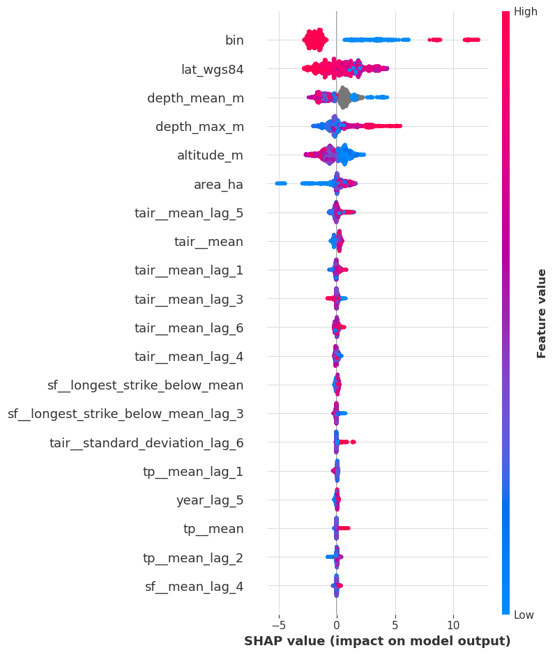

```python
shap.summary_plot(shap_values, X_test, feature_names=feature_names)
```

```python
shap_interaction_values = explainer.shap_interaction_values(X_test)
```

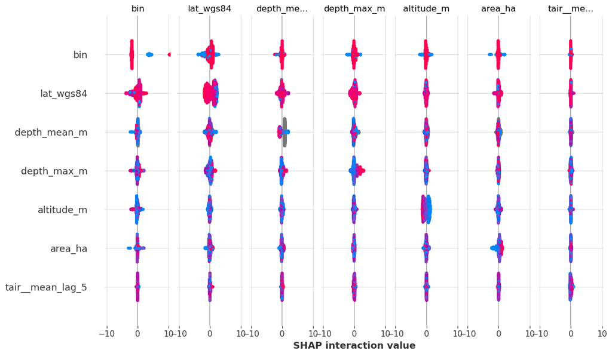

```python
shap.summary_plot(shap_interaction_values, X_test,feature_names=feature_names)
```